# Project 1: EDA & Modeling

### Vietnam Model

You will use some of the datasets and summaries here that you created in the **Vietnam EDA** problem.

**The Problem**

How can we further explore the question of randomness via regression modeling?

**Linear Model 1**

The newspaper article that examined the draft lottery results (discussed earlier in Vietnam EDA) also contained the following observation: “The general decline in the average monthly numbers can be seen if a graph is constructed, with the months from January through December along the horizontal axis and the average numbers plotted vertically. The points reach a high in March and then fall in an almost linear progression through December.” Use your saved calculations from the Vietnam EDA problem.

- Create a plot like the one described in the newspaper.
- Include a fitted least squares line on the scatterplot.
- Fit the least squares linear model and display results.
  - regression coefficients
  - R<sup>2</sup>, MSE, RMSE, sigma

The Plot

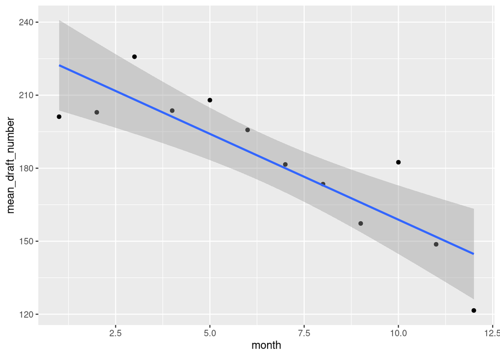

```r
ggplot(monthly_mean_draft_number, aes(x=month, y=mean_draft_number)) + geom_point() + geom_smooth(method="lm")
```

The Model

```r
model <- lm(month ~ mean_draft_number, data=monthly_mean_draft_number)
get_regression_summaries(model)
```

```
# A tibble: 1 x 9
  r_squared adj_r_squared   mse  rmse sigma statistic p_value    df  nobs
      <dbl>         <dbl> <dbl> <dbl> <dbl>     <dbl>   <dbl> <dbl> <dbl>
1     0.751         0.726  2.97  1.72  1.89      30.1       0     1    12
```

**Linear Model 2**

Creating regression models using averages is often frowned upon, since averages will always have less variability than the individual data points. The coefficients of the models may also be quite different, depending on the scatter of the individual points. Use the `draft1970` dataset here to conduct the same analysis using the individual data points.

- Create a plot like the one described in the newspaper.
- Include a fitted least squares line on the scatterplot.
- Fit the least squares linear model and display results.
  - regression coefficients
  - R<sup>2</sup>, MSE, RMSE, sigma

The Plot

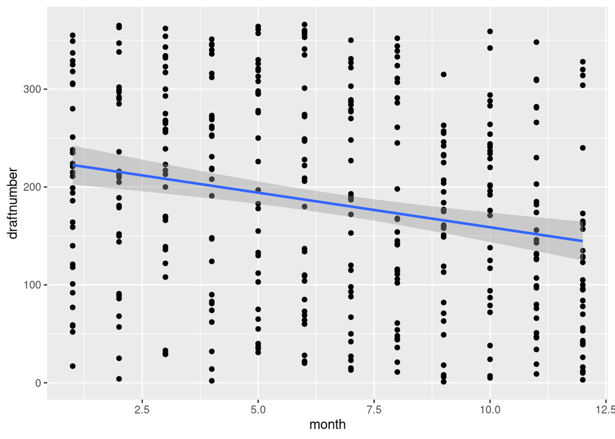

```r
ggplot(draft1970, aes(x=month, y=draftnumber)) + geom_point() + geom_smooth(method="lm")
```

The Model

```r
model <- lm(month ~ draftnumber, data=draft1970)
get_regression_summaries(model)
```

```
# A tibble: 1 x 9
  r_squared adj_r_squared   mse  rmse sigma statistic p_value    df  nobs
      <dbl>         <dbl> <dbl> <dbl> <dbl>     <dbl>   <dbl> <dbl> <dbl>
1     0.053         0.051  11.3  3.36  3.37      20.5       0     1   366
```

**Discussion of Results**

Question 1: What would you expect the slope of the least-squares regression line, the Pearson correlation coefficient, and R<sup>2</sup> to be if the 1970 draft lottery was truly random? Explain.

Question 2: How does this analysis support the idea that the lottery was not truly random and was biased against those born in the second half of the year? Explain using information from both of your models.